# CFA_RMARKDOWN

# Preliminary analysis

Quick glance at the frequencies of demographics. We have very little respondents in many categories, which will mess up our analysis later on, so I decided to combine or remove some of them.

```
## rawdata_df$Q4
##                                                                                                             Frequency
## Full Working Proficiency (Able to converse easily about everyday things and don’t need to search for words)        71
## Native/Bilingual Proficiency (Proficient at conversing about everyday things and at complex/higher levels)        382
## Total                                                                                                             453
##                                                                                                             Percent
## Full Working Proficiency (Able to converse easily about everyday things and don’t need to search for words)   15.67
## Native/Bilingual Proficiency (Proficient at conversing about everyday things and at complex/higher levels)    84.33
## Total                                                                                                        100.00
```

```
## rawdata_df$Q5
##                 Frequency Percent
## 18-24 years old        15   3.311
## 25-34 years old       154  33.996
## 35-44 years old       156  34.437
## 45-54 years old        74  16.336
## 55-64 years old        44   9.713
## 65-74 years old        10   2.208
## Total                 453 100.000
```

```
## rawdata_df$Q6
##                                       Frequency  Percent
## Full time (30+ hours a week)                373  82.3400
## Part time (Less than 30 hours a week)        19   4.1943
## Self-employed                                38   8.3885
## Student and employed                          3   0.6623
## Student not employed                          1   0.2208
## Unemployed less than 6 months                 4   0.8830
## Unemployed longer than 6 months              15   3.3113
## Total                                       453 100.0000
```

```
## rawdata_df$Q7
##              Frequency  Percent Valid Percent
## 1-2 years           15   3.3113         3.326
## 11-15 years         66  14.5695        14.634
## 3-5 years           71  15.6733        15.743
## 6-10 years         114  25.1656        25.277
## More than 15       185  40.8389        41.020
## NA's                 2   0.4415
## Total              453 100.0000       100.000
```

```
## rawdata_df$Q8
##                  Frequency Percent
## 0-6 months              19   4.194
## 1-2 years               63  13.907
## 11-15 years             41   9.051
## 16-25 years             27   5.960
## 25 years or more        11   2.428
## 3-5 years              174  38.411
## 6-10 years             111  24.503
## 7-12 months              7   1.545
## Total                  453 100.000
```

```
## rawdata_df$Q9
##                                                 Frequency  Percent
##                                                         1   0.2208
## African-American/Black (not Hispanic or Latino)        40   8.8300
## Asian                                                  56  12.3620
## Caucasian/White (not Hispanic or Latino)              317  69.9779
## Hispanic or Latino                                     23   5.0773
## Native American or Alaskan Native                      12   2.6490
## Two or more races                                       4   0.8830
## Total                                                 453 100.0000
```

```
## rawdata_df$Q10
##                      Frequency  Percent
## Female                     186  41.0596
## Male                       265  58.4989
## Non-binary or other          1   0.2208
## Prefer not to answer         1   0.2208
## Total                      453 100.0000
```

```
## rawdata_df$Q11
##                               Frequency  Percent
##                                       1   0.2208
## Africa                                1   0.2208
## Asia                                 44   9.7130
## Europe                                6   1.3245
## North America/Central America       366  80.7947
## South America                        35   7.7263
## Total                               453 100.0000
```

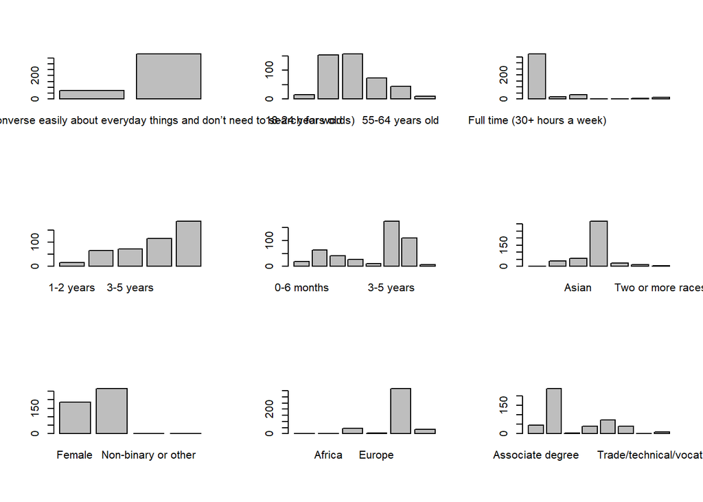

```
## rawdata_df$Q12
##                                   Frequency  Percent
## Associate degree                         46  10.1545
## Bachelor’s degree                       239  52.7594
## Doctorate degree                          5   1.1038
## High school diploma or equivalent        39   8.6093
## Master’s degree                          74  16.3355
## Some college credit                      39   8.6093
## Some high school, no diploma              1   0.2208
## Trade/technical/vocational               10   2.2075
## Total                                   453 100.0000
```

For Q5, I combined ‘18-24 years old’, ‘55-64 years old’, and ‘65-74 years old’ into the category ‘Other’ (even combined they only add up to 69 respondents, which is 15% of the data). For Q6, I combined all categories that weren’t full time employees into Other (and even then, they only make up 17% of the data). For Q7, I combined ‘1-2 years’, and ‘3-5 years’ into ‘1-5 years’. For Q8, I combined ‘0-6 months’, ‘7-12 months’, and ‘1-2 years’ into ‘0-2 years’. Also, ‘11-15 years’, ‘16-25 years’, and ‘25 years or more’ into ‘11-25 years or more’. For Q9, I just combined everything that is not caucasian into ‘Other’. For Q10, I just removed the non-gender categories, since literally only 2 people responded to those. For Q11, I combined everything that is not North America/central. Finally, for Q12 I combined everything that is below a bachelor’s degree into ‘Below Bachelors’, and I combined doctoral and master degree into “Grad School Degree”. For the other demographic data, categories are so different I don’t think I can combine them in a logical way.

```
## rawdata_df$Q4
##                                                                                                             Frequency
## Full Working Proficiency (Able to converse easily about everyday things and don’t need to search for words)        70
## Native/Bilingual Proficiency (Proficient at conversing about everyday things and at complex/higher levels)        381
## Total                                                                                                             451
##                                                                                                             Percent
## Full Working Proficiency (Able to converse easily about everyday things and don’t need to search for words)   15.52
## Native/Bilingual Proficiency (Proficient at conversing about everyday things and at complex/higher levels)    84.48
## Total                                                                                                        100.00
```

```
## rawdata_df$Q5
##                 Frequency Percent
## 25-34 years old       154   34.15
## 35-44 years old       155   34.37
## 45-54 years old        74   16.41
## Other                  68   15.08
## Total                 451  100.00
```

```
## rawdata_df$Q6
##                              Frequency Percent
## Full time (30+ hours a week)       372   82.48
## Other                               79   17.52
## Total                              451  100.00
```

```
## rawdata_df$Q7
##              Frequency  Percent Valid Percent
## 1-5 years           85  18.8470         18.93
## 11-15 years         66  14.6341         14.70
## 6-10 years         113  25.0554         25.17
## More than 15       185  41.0200         41.20
## NA's                 2   0.4435
## Total              451 100.0000        100.00
```

```
## rawdata_df$Q8
##                     Frequency Percent
## 0-2 years                  88   19.51
## 11-25 years or more        79   17.52
## 3-5 years                 174   38.58
## 6-10 years                110   24.39
## Total                     451  100.00
```

```
## rawdata_df$Q9
##                                          Frequency Percent
## Caucasian/White (not Hispanic or Latino)       316   70.07
## Other                                          135   29.93
## Total                                          451  100.00
```

```
## rawdata_df$Q10
##        Frequency Percent
## Female       186   41.24
## Male         265   58.76
## Total        451  100.00
```

```
## rawdata_df$Q11
##                               Frequency Percent
## North America/Central America       365   80.93
## Other                                86   19.07
## Total                               451  100.00
```

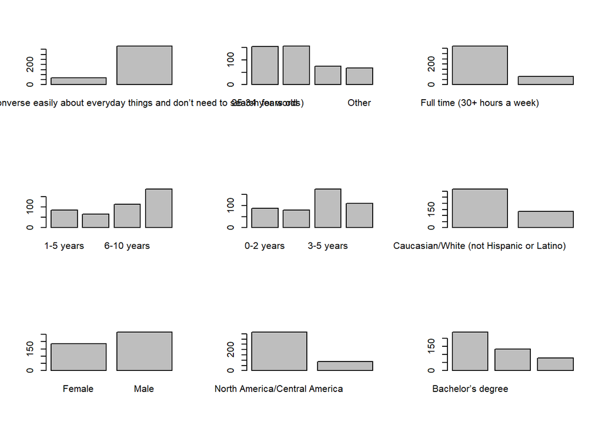

```
## rawdata_df$Q12
##                    Frequency Percent
## Bachelor’s degree        238   52.77
## Below Bachelors          134   29.71
## Grad School Degree        79   17.52
## Total                    451  100.00
```

## Criterion validity analysis

Cooperation and **engageable** are significant predictors of OCBs.

```
##
## Call:
## lm(formula = OCB ~ ., data = regOCB)
##
## Residuals:
##      Min       1Q   Median       3Q      Max
## -1.79175 -0.35886 -0.01456  0.35824  1.93923
##
## Coefficients:
##                       Estimate Std. Error t value Pr(>|t|)
## (Intercept)          -0.561711   0.827197  -0.679  0.49767
## Achievement_Oriented  0.160026   0.112159   1.427  0.15477
## Adaptable             0.027971   0.124839   0.224  0.82288
## Analytical_Thinking   0.134739   0.093991   1.434  0.15284
## Assertive             0.069579   0.105766   0.658  0.51117
## Competitive           0.068245   0.059884   1.140  0.25544
## Creative              0.094539   0.083838   1.128  0.26045
## Dependability         0.124467   0.116995   1.064  0.28832
## Detail_Oriented      -0.188898   0.101131  -1.868  0.06284 .
## Energetic             0.116879   0.072141   1.620  0.10634
## Influencing           0.024768   0.095050   0.261  0.79461
## Initiative           -0.084493   0.118752  -0.712  0.47737
## Learning_Orientation -0.057844   0.120244  -0.481  0.63086
## Methodical            0.038237   0.093327   0.410  0.68234
## Optimism             -0.027838   0.073871  -0.377  0.70658
## Persistence           0.087384   0.114434   0.764  0.44575
## Rule_Follower         0.053377   0.085372   0.625  0.53234
## Self_control         -0.111408   0.098041  -1.136  0.25680
## Team_Oriented        -0.019025   0.087460  -0.218  0.82796
## Stress_Tolerance     -0.122093   0.083044  -1.470  0.14264
## Cooperation           0.245933   0.104673   2.350  0.01950 *
## Concern_for_Others   -0.001358   0.110687  -0.012  0.99022
## Multitasking          0.079451   0.063230   1.257  0.20998
## Mindful               0.038619   0.096550   0.400  0.68947
## Principled            0.066608   0.085341   0.780  0.43577
## Engageable            0.274336   0.089344   3.071  0.00235 **
## Social_Desirability  -0.167680   0.114358  -1.466  0.14371
## Patience              0.051092   0.069710   0.733  0.46423
## Though_mind          -0.142458   0.088282  -1.614  0.10774
## Sincerity            -0.079246   0.098935  -0.801  0.42383
## Sociability          -0.010214   0.080760  -0.126  0.89945
## Hexaco                0.196308   0.134005   1.465  0.14408
## ---
## Signif. codes:  0 '***' 0.001 '**' 0.01 '*' 0.05 '.' 0.1 ' ' 1
##
## Residual standard error: 0.5968 on 276 degrees of freedom
##   (1 observation deleted due to missingness)
## Multiple R-squared:  0.5165, Adjusted R-squared:  0.4622
## F-statistic:  9.51 on 31 and 276 DF,  p-value: < 2.2e-16
```

```
##
## Call:
## lm(formula = CWB ~ ., data = regCWB)
##
## Residuals:
##      Min       1Q   Median       3Q      Max
## -1.71267 -0.39132 -0.04469  0.34745  1.99418
##
## Coefficients:
##                       Estimate Std. Error t value Pr(>|t|)
## (Intercept)           5.936427   0.891715   6.657 1.50e-10 ***
## Achievement_Oriented  0.033804   0.120907   0.280  0.78001
## Adaptable            -0.074545   0.134576  -0.554  0.58008
## Analytical_Thinking  -0.010737   0.101322  -0.106  0.91569
## Assertive            -0.131508   0.114015  -1.153  0.24974
## Competitive          -0.006588   0.064555  -0.102  0.91879
## Creative             -0.022089   0.090377  -0.244  0.80710
## Dependability        -0.046534   0.126121  -0.369  0.71244
## Detail_Oriented       0.016001   0.109019   0.147  0.88342
## Energetic            -0.050240   0.077768  -0.646  0.51880
## Influencing           0.159174   0.102463   1.553  0.12146
## Initiative           -0.009356   0.128014  -0.073  0.94179
## Learning_Orientation -0.090842   0.129622  -0.701  0.48400
## Methodical            0.161376   0.100607   1.604  0.10985
## Optimism              0.022560   0.079633   0.283  0.77715
## Persistence           0.070364   0.123360   0.570  0.56887
## Rule_Follower        -0.132050   0.092030  -1.435  0.15246
## Self_control          0.113117   0.105688   1.070  0.28542
## Team_Oriented        -0.074722   0.094281  -0.793  0.42873
## Stress_Tolerance     -0.146371   0.089522  -1.635  0.10318
## Cooperation           0.051797   0.112837   0.459  0.64657
## Concern_for_Others    0.254753   0.119320   2.135  0.03364 *
## Multitasking         -0.057014   0.068161  -0.836  0.40362
## Mindful              -0.436343   0.104080  -4.192 3.72e-05 ***
## Principled           -0.254918   0.091997  -2.771  0.00597 **
## Engageable            0.026992   0.096312   0.280  0.77949
## Social_Desirability  -0.127971   0.123278  -1.038  0.30015
## Patience              0.104469   0.075147   1.390  0.16559
## Though_mind           0.376274   0.095168   3.954 9.78e-05 ***
## Sincerity            -0.115945   0.106652  -1.087  0.27793
## Sociability           0.099044   0.087059   1.138  0.25624
## Hexaco               -0.414005   0.144457  -2.866  0.00448 **
## ---
## Signif. codes:  0 '***' 0.001 '**' 0.01 '*' 0.05 '.' 0.1 ' ' 1
##
## Residual standard error: 0.6433 on 276 degrees of freedom
##   (1 observation deleted due to missingness)
## Multiple R-squared:  0.5789, Adjusted R-squared:  0.5316
## F-statistic: 12.24 on 31 and 276 DF,  p-value: < 2.2e-16
```

```
##
## Call:
## lm(formula = Task_performance ~ ., data = regTaskPersormance)
##
## Residuals:
##      Min       1Q   Median       3Q      Max
## -2.41581 -0.36534  0.04446  0.41106  1.51281
##
## Coefficients:
##                       Estimate Std. Error t value Pr(>|t|)
## (Intercept)           0.426792   0.848201   0.503 0.615244
## Achievement_Oriented  0.103289   0.115007   0.898 0.369907
## Adaptable            -0.068651   0.128009  -0.536 0.592184
## Analytical_Thinking   0.074090   0.096378   0.769 0.442706
## Assertive             0.109249   0.108452   1.007 0.314649
## Competitive          -0.057036   0.061405  -0.929 0.353777
## Creative              0.110367   0.085967   1.284 0.200279
## Dependability         0.218094   0.119966   1.818 0.070153 .
## Detail_Oriented      -0.188314   0.103699  -1.816 0.070461 .
## Energetic             0.001726   0.073973   0.023 0.981406
## Influencing          -0.006849   0.097463  -0.070 0.944030
## Initiative           -0.215943   0.121767  -1.773 0.077264 .
## Learning_Orientation  0.029990   0.123297   0.243 0.808006
## Methodical            0.019339   0.095697   0.202 0.839996
## Optimism             -0.080247   0.075747  -1.059 0.290342
## Persistence           0.104486   0.117340   0.890 0.373997
## Rule_Follower        -0.013777   0.087540  -0.157 0.875061
## Self_control          0.109936   0.100531   1.094 0.275104
## Team_Oriented        -0.035162   0.089681  -0.392 0.695299
## Stress_Tolerance      0.102381   0.085153   1.202 0.230273
## Cooperation           0.089972   0.107331   0.838 0.402606
## Concern_for_Others   -0.167515   0.113497  -1.476 0.141102
## Multitasking          0.113233   0.064835   1.746 0.081842 .
## Mindful               0.348550   0.099001   3.521 0.000503 ***
## Principled           -0.001310   0.087508  -0.015 0.988069
## Engageable            0.160093   0.091613   1.748 0.081662 .
## Social_Desirability  -0.036815   0.117262  -0.314 0.753791
## Patience             -0.021473   0.071480  -0.300 0.764090
## Though_mind          -0.168926   0.090524  -1.866 0.063089 .
## Sincerity             0.090663   0.101448   0.894 0.372266
## Sociability          -0.102335   0.082811  -1.236 0.217595
## Hexaco                0.300836   0.137408   2.189 0.029408 *
## ---
## Signif. codes:  0 '***' 0.001 '**' 0.01 '*' 0.05 '.' 0.1 ' ' 1
##
## Residual standard error: 0.6119 on 276 degrees of freedom
##   (1 observation deleted due to missingness)
## Multiple R-squared:  0.4641, Adjusted R-squared:  0.4039
## F-statistic: 7.711 on 31 and 276 DF,  p-value: < 2.2e-16
```

```
##
## Call:
## lm(formula = Intention_to_stay ~ ., data = regIntentionToStay)
##
## Residuals:
##    Min     1Q Median     3Q    Max
## -4.316 -1.097 -0.068  1.121  4.200
##
## Coefficients:
##                      Estimate Std. Error t value Pr(>|t|)
## (Intercept)           6.72181    2.17981   3.084  0.00226 **
## Achievement_Oriented  0.33452    0.30104   1.111  0.26748
## Adaptable             0.41170    0.33561   1.227  0.22100
## Analytical_Thinking  -0.18576    0.24889  -0.746  0.45610
## Assertive            -0.62785    0.28932  -2.170  0.03087 *
## Competitive          -0.03863    0.15909  -0.243  0.80834
## Creative              0.03673    0.22781   0.161  0.87205
## Dependability        -0.31261    0.31003  -1.008  0.31421
## Detail_Oriented      -0.38971    0.26957  -1.446  0.14943
## Energetic            -0.32342    0.19099  -1.693  0.09154 .
## Influencing           0.59090    0.26121   2.262  0.02448 *
## Initiative            0.74462    0.31715   2.348  0.01961 *
## Learning_Orientation  0.06779    0.31748   0.214  0.83107
## Methodical            0.32069    0.24611   1.303  0.19367
## Optimism              0.05616    0.19711   0.285  0.77592
## Persistence           0.20684    0.30286   0.683  0.49522
## Rule_Follower        -0.06816    0.22495  -0.303  0.76212
## Self_control          0.37670    0.25875   1.456  0.14661
## Team_Oriented         0.14332    0.23292   0.615  0.53887
## Stress_Tolerance     -0.72185    0.22011  -3.279  0.00118 **
## Cooperation           0.30347    0.27519   1.103  0.27111
## Concern_for_Others    0.34274    0.29776   1.151  0.25074
## Multitasking         -0.16928    0.16859  -1.004  0.31624
## Mindful              -0.58213    0.25551  -2.278  0.02349 *
## Principled           -0.05276    0.23052  -0.229  0.81915
## Engageable           -0.74227    0.24060  -3.085  0.00225 **
## Social_Desirability   0.01703    0.30387   0.056  0.95535
## Patience              0.32145    0.18447   1.743  0.08254 .
## Though_mind           0.63968    0.23853   2.682  0.00778 **
## Sincerity            -0.37983    0.26195  -1.450  0.14821
## Sociability          -0.28155    0.21835  -1.289  0.19836
## Hexaco               -0.72341    0.36165  -2.000  0.04647 *
## ---
## Signif. codes:  0 '***' 0.001 '**' 0.01 '*' 0.05 '.' 0.1 ' ' 1
##
## Residual standard error: 1.564 on 269 degrees of freedom
##   (8 observations deleted due to missingness)
## Multiple R-squared:  0.4675, Adjusted R-squared:  0.4061
## F-statistic: 7.618 on 31 and 269 DF,  p-value: < 2.2e-16
```

```
##
## Call:
## lm(formula = Engagement ~ ., data = regEngagement)
##
## Residuals:
##      Min       1Q   Median       3Q      Max
## -1.07988 -0.18322 -0.00191  0.19514  1.10104
##
## Coefficients:
##                        Estimate Std. Error t value Pr(>|t|)
## (Intercept)          -2.0021365  0.4501763  -4.447 1.26e-05 ***
## Achievement_Oriented -0.2318455  0.0605704  -3.828 0.000160 ***
## Adaptable             0.1699890  0.0675014   2.518 0.012356 *
## Analytical_Thinking   0.1816042  0.0512727   3.542 0.000466 ***
## Assertive             0.0771345  0.0570806   1.351 0.177694
## Competitive          -0.0408319  0.0326939  -1.249 0.212751
## Creative              0.0431629  0.0457023   0.944 0.345770
## Dependability        -0.0697281  0.0637173  -1.094 0.274758
## Detail_Oriented       0.0059589  0.0551541   0.108 0.914041
## Energetic             0.1051207  0.0394058   2.668 0.008088 **
## Influencing           0.0230062  0.0513667   0.448 0.654588
## Initiative           -0.0333750  0.0644966  -0.517 0.605242
## Learning_Orientation -0.1163371  0.0656828  -1.771 0.077628 .
## Methodical            0.0290649  0.0501272   0.580 0.562505
## Optimism              0.0089626  0.0398315   0.225 0.822135
## Persistence          -0.1107747  0.0618364  -1.791 0.074318 .
## Rule_Follower        -0.0269271  0.0461432  -0.584 0.559994
## Self_control         -0.1051825  0.0535459  -1.964 0.050490 .
## Team_Oriented         0.0044597  0.0477348   0.093 0.925633
## Stress_Tolerance      0.0709536  0.0453387   1.565 0.118732
## Cooperation          -0.0388395  0.0571626  -0.679 0.497416
## Concern_for_Others   -0.1748188  0.0602852  -2.900 0.004032 **
## Multitasking          0.1054097  0.0345000   3.055 0.002467 **
## Mindful              -0.1123672  0.0526657  -2.134 0.033755 *
## Principled           -0.1685682  0.0464369  -3.630 0.000337 ***
## Engageable            1.7360858  0.0483763  35.887  < 2e-16 ***
## Social_Desirability   0.0446414  0.0622464   0.717 0.473872
## Patience              0.0307018  0.0380868   0.806 0.420877
## Though_mind          -0.0015395  0.0482332  -0.032 0.974561
## Sincerity             0.0001178  0.0537394   0.002 0.998253
## Sociability          -0.0132036  0.0440382  -0.300 0.764538
## Hexaco                0.0545991  0.0732136   0.746 0.456450
## ---
## Signif. codes:  0 '***' 0.001 '**' 0.01 '*' 0.05 '.' 0.1 ' ' 1
##
## Residual standard error: 0.3261 on 277 degrees of freedom
## Multiple R-squared:  0.925,  Adjusted R-squared:  0.9166
## F-statistic: 110.2 on 31 and 277 DF,  p-value: < 2.2e-16
```

```
##
## Call:
## lm(formula = Incivility ~ ., data = regIncivility)
##
## Residuals:
##      Min       1Q   Median       3Q      Max
## -1.90508 -0.48232 -0.00852  0.40313  2.45998
##
## Coefficients:
##                        Estimate Std. Error t value Pr(>|t|)
## (Intercept)           4.1360838  1.0835494   3.817 0.000167 ***
## Achievement_Oriented -0.0216207  0.1457895  -0.148 0.882213
## Adaptable             0.0006058  0.1624720   0.004 0.997028
## Analytical_Thinking   0.0943382  0.1234104   0.764 0.445264
## Assertive             0.0150670  0.1373898   0.110 0.912754
## Competitive          -0.0665813  0.0786924  -0.846 0.398230
## Creative              0.0102542  0.1100028   0.093 0.925798
## Dependability         0.0322754  0.1533641   0.210 0.833471
## Detail_Oriented      -0.1727474  0.1327529  -1.301 0.194247
## Energetic            -0.0115110  0.0948477  -0.121 0.903491
## Influencing           0.1251896  0.1236368   1.013 0.312154
## Initiative            0.1530432  0.1552398   0.986 0.325067
## Learning_Orientation -0.2721413  0.1580949  -1.721 0.086298 .
## Methodical            0.2183924  0.1206534   1.810 0.071367 .
## Optimism              0.0468247  0.0958721   0.488 0.625648
## Persistence           0.0031607  0.1488367   0.021 0.983073
## Rule_Follower        -0.0135338  0.1110642  -0.122 0.903102
## Self_control          0.1835145  0.1288820   1.424 0.155602
## Team_Oriented         0.0153873  0.1148949   0.134 0.893559
## Stress_Tolerance     -0.2942782  0.1091278  -2.697 0.007433 **
## Cooperation           0.1712978  0.1375873   1.245 0.214180
## Concern_for_Others    0.0805298  0.1451032   0.555 0.579354
## Multitasking         -0.0990131  0.0830396  -1.192 0.234140
## Mindful              -0.3482271  0.1267633  -2.747 0.006407 **
## Principled           -0.3072898  0.1117710  -2.749 0.006365 **
## Engageable            0.1947560  0.1164391   1.673 0.095535 .
## Social_Desirability  -0.0310142  0.1498237  -0.207 0.836158
## Patience              0.1335019  0.0916729   1.456 0.146446
## Though_mind           0.3433526  0.1160946   2.958 0.003369 **
## Sincerity            -0.1665775  0.1293478  -1.288 0.198881
## Sociability          -0.1072114  0.1059975  -1.011 0.312683
## Hexaco               -0.3003392  0.1762211  -1.704 0.089440 .
## ---
## Signif. codes:  0 '***' 0.001 '**' 0.01 '*' 0.05 '.' 0.1 ' ' 1
##
## Residual standard error: 0.7848 on 277 degrees of freedom
## Multiple R-squared:  0.4192, Adjusted R-squared:  0.3542
## F-statistic: 6.448 on 31 and 277 DF,  p-value: < 2.2e-16
```

Assertive, **creative**, influencing, and engageable are significant predictors of idk.

```
##
## Call:
## lm(formula = IDK ~ ., data = regIDK)
##
## Residuals:
##      Min       1Q   Median       3Q      Max
## -1.61165 -0.27100  0.03837  0.33185  1.13138
##
## Coefficients:
##                       Estimate Std. Error t value Pr(>|t|)
## (Intercept)           0.793837   0.676253   1.174  0.24146
## Achievement_Oriented  0.120536   0.091692   1.315  0.18975
## Adaptable             0.135703   0.102059   1.330  0.18473
## Analytical_Thinking   0.123131   0.076840   1.602  0.11021
## Assertive             0.178219   0.086466   2.061  0.04023 *
## Competitive           0.074743   0.048957   1.527  0.12798
## Creative              0.171714   0.068540   2.505  0.01281 *
## Dependability         0.101086   0.095647   1.057  0.29150
## Detail_Oriented       0.076550   0.082677   0.926  0.35531
## Energetic             0.008365   0.058977   0.142  0.88732
## Influencing          -0.166028   0.077705  -2.137  0.03351 *
## Initiative           -0.005163   0.097082  -0.053  0.95762
## Learning_Orientation -0.151681   0.098302  -1.543  0.12397
## Methodical            0.012872   0.076297   0.169  0.86615
## Optimism             -0.052117   0.060391  -0.863  0.38889
## Persistence          -0.049681   0.093553  -0.531  0.59581
## Rule_Follower         0.016435   0.069793   0.235  0.81401
## Self_control         -0.102137   0.080151  -1.274  0.20363
## Team_Oriented        -0.093427   0.071501  -1.307  0.19242
## Stress_Tolerance      0.051648   0.067891   0.761  0.44746
## Cooperation          -0.046594   0.085572  -0.544  0.58654
## Concern_for_Others   -0.153712   0.090489  -1.699  0.09051 .
## Multitasking          0.034806   0.051692   0.673  0.50130
## Mindful               0.162203   0.078932   2.055  0.04082 *
## Principled           -0.003232   0.069768  -0.046  0.96308
## Engageable            0.202518   0.073041   2.773  0.00594 **
## Social_Desirability   0.042210   0.093491   0.451  0.65199
## Patience             -0.026559   0.056990  -0.466  0.64156
## Though_mind          -0.035205   0.072173  -0.488  0.62609
## Sincerity            -0.088488   0.080882  -1.094  0.27489
## Sociability           0.059660   0.066023   0.904  0.36698
## Hexaco                0.106911   0.109553   0.976  0.32998
## ---
## Signif. codes:  0 '***' 0.001 '**' 0.01 '*' 0.05 '.' 0.1 ' ' 1
##
## Residual standard error: 0.4879 on 276 degrees of freedom
##   (1 observation deleted due to missingness)
## Multiple R-squared:  0.4054, Adjusted R-squared:  0.3386
## F-statistic: 6.071 on 31 and 276 DF,  p-value: < 2.2e-16
```

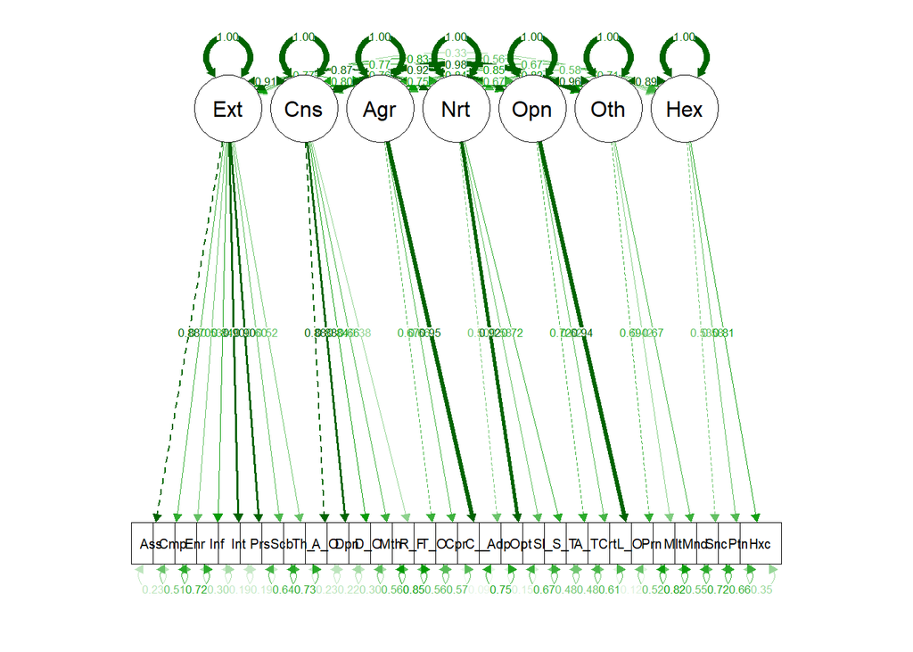

```
##
## Reliability analysis
## Call: alpha(x = extraversion)
##
##   raw_alpha std.alpha G6(smc) average_r S/N    ase mean   sd median_r
##        0.9      0.91    0.93      0.54 9.6 0.0078  4.7 0.66     0.56
##
##  lower alpha upper     95% confidence boundaries
## 0.89 0.9 0.92
##
##  Reliability if an item is dropped:
##             raw_alpha std.alpha G6(smc) average_r  S/N alpha se var.r med.r
## Assertive        0.88      0.88    0.90      0.51  7.2   0.0101 0.033  0.52
## Competitive      0.89      0.89    0.91      0.54  8.1   0.0090 0.038  0.55
## Energetic        0.91      0.91    0.93      0.60 10.7   0.0075 0.025  0.61
## Influencing      0.87      0.88    0.90      0.51  7.2   0.0104 0.034  0.52
## Initiative       0.89      0.88    0.90      0.52  7.7   0.0092 0.036  0.57
## Persistence      0.88      0.88    0.90      0.52  7.6   0.0093 0.036  0.55
## Sociability      0.90      0.90    0.92      0.57  9.3   0.0080 0.036  0.58
## Though_mind      0.90      0.91    0.92      0.59  9.9   0.0081 0.027  0.58
##
##  Item statistics
##               n raw.r std.r r.cor r.drop mean   sd
## Assertive   309  0.91  0.91  0.91   0.87  5.0 0.82
## Competitive 309  0.83  0.80  0.77   0.74  4.6 1.15
## Energetic   309  0.54  0.57  0.48   0.44  4.4 0.68
## Influencing 309  0.91  0.90  0.90   0.87  4.9 0.91
## Initiative  309  0.83  0.85  0.84   0.78  5.3 0.76
## Persistence 309  0.84  0.85  0.85   0.79  5.3 0.76
## Sociability 309  0.69  0.68  0.63   0.59  4.3 0.87
## Though_mind 309  0.64  0.64  0.58   0.55  4.3 0.76
```